# MP2

**MP2 Telling a Visual Narrative of your Data**

**FIFA World Cup Data Analysis** **Dataset:** FIFA World Cup Summary (1930–2022)  
**Analyst:** [Anthony Valdez-Cruz]  
**Context:** As FIFA's data analyst, we explore historical World Cup trends to provide actionable insights for the 2026 World Cup taking place in the United States, Canada, and Mexio

```python
#Importing libraries
import pandas as pd
import matplotlib.pyplot as plt
```

```python
#Loading the dataset
df = pd.read_csv('FIFAWorldCupSummary.csv')

#Data cleaning
print('df.shape:', df.shape)
# Checking for missing values
print(df.isnull().sum())
# Check data types
print(df.dtypes)

# Drop any rows with missing values (if any)
df = df.dropna()
print(df.shape)
```

```
df.shape: (22, 9)
YEAR                  0
HOST                  0
CHAMPION              0
RUNNER UP             0
THIRD PLACE           0
TEAMS                 0
MATCHES PLAYED        0
GOALS SCORED          0
AVG GOALS PER GAME    0
dtype: int64
YEAR                    int64
HOST                   object
CHAMPION               object
RUNNER UP              object
THIRD PLACE            object
TEAMS                   int64
MATCHES PLAYED          int64
GOALS SCORED            int64
AVG GOALS PER GAME    float64
dtype: object
(22, 9)
```

**Fig 1:Championship Wins by Country:** Which countries have won the most World Cups? Here we count total wins per country, filtering to only those with 2 or more titles to keep the chart readable.

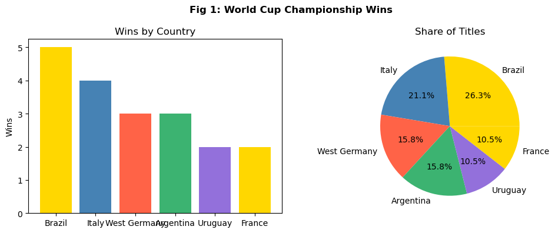

```python
# Figure 1: World Cup Championship Wins
champion_counts = df['CHAMPION'].value_counts()
champion_counts = champion_counts[champion_counts > 1]

colors = ['gold', 'steelblue', 'tomato', 'mediumseagreen', 'mediumpurple']

fig, (ax1, ax2) = plt.subplots(1, 2, figsize=(10, 4))

ax1.bar(champion_counts.index, champion_counts.values, color=colors)
ax1.set_title('Wins by Country')
ax1.set_ylabel('Wins')

ax2.pie(champion_counts.values, labels=champion_counts.index, colors=colors, autopct='%1.1f%%')
ax2.set_title('Share of Titles')

plt.suptitle('Fig 1: World Cup Championship Wins', fontweight='bold')
plt.tight_layout()
plt.show()
```

Fig 1: Total World Cup wins by country, showing Brazil as the most dominant nation with 5 championships.

**Fig 2: Average Goals Per Game Over Time:** Has the World Cup become more or less exciting over the years? This line chart tracks the average goals scored per game across every tournament since 1930.

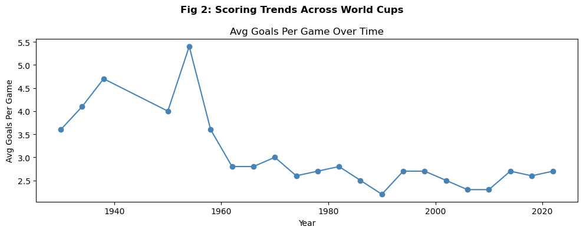

```python
# Figure 2: Average Goals Per Game Over Time
fig, ax = plt.subplots(figsize=(10, 4))

ax.plot(df['YEAR'], df['AVG GOALS PER GAME'], color='steelblue', marker='o')
ax.set_title('Avg Goals Per Game Over Time')
ax.set_xlabel('Year')
ax.set_ylabel('Avg Goals Per Game')

plt.suptitle('Fig 2: Scoring Trends Across World Cups', fontweight='bold')
plt.tight_layout()
plt.show()
```

**Fig 3: Tournament Growth Over Time:** How has the World Cup grown as a tournament? This line chart tracks the number of teams and matches played across every World Cup since 1930.

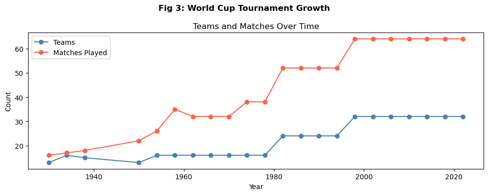

```python
#Figure 3: Growth of Teams and Matches Over Time
fig, ax = plt.subplots(figsize=(10, 4))

ax.plot(df['YEAR'], df['TEAMS'], color='steelblue', marker='o', label='Teams')
ax.plot(df['YEAR'], df['MATCHES PLAYED'], color='tomato', marker='o', label='Matches Played')
ax.set_title('Teams and Matches Over Time')
ax.set_xlabel('Year')
ax.set_ylabel('Count')
ax.legend()

plt.suptitle('Fig 3: World Cup Tournament Growth', fontweight='bold')
plt.tight_layout()
plt.show()
```

Fig 3: Growth of the World Cup tournament over time, showing significant jumps in teams and matches in 1982 and 1998.

**Fig 4: Top 10 Countries by Podium Finishes:** Which countries have been the most consistently dominant? Here we count total top 3 finishes (1st, 2nd, and 3rd place) for each country.

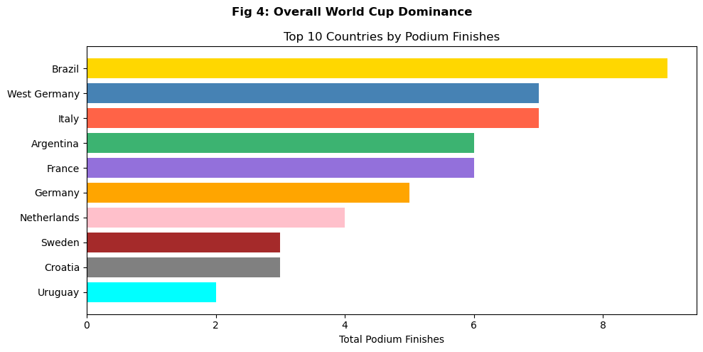

```python
# Figure 4: Overall World Cup Dominance
podium = pd.concat([df['CHAMPION'], df['RUNNER UP'], df['THIRD PLACE']])


podium_counts = podium.value_counts().head(10)

colors = ['gold', 'steelblue', 'tomato', 'mediumseagreen', 'mediumpurple',
          'orange', 'pink', 'brown', 'gray', 'cyan']

fig, ax = plt.subplots(figsize=(10, 5))

ax.barh(podium_counts.index[::-1], podium_counts.values[::-1], color=colors[::-1])
ax.set_title('Top 10 Countries by Podium Finishes')
ax.set_xlabel('Total Podium Finishes')

plt.suptitle('Fig 4: Overall World Cup Dominance', fontweight='bold')
plt.tight_layout()
plt.show()
```

**Fig 5: Host Country Performance:** Does hosting the World Cup give a country an advantage? Here we check whether each host country finished in 1st, 2nd, 3rd place, or did not place at all.

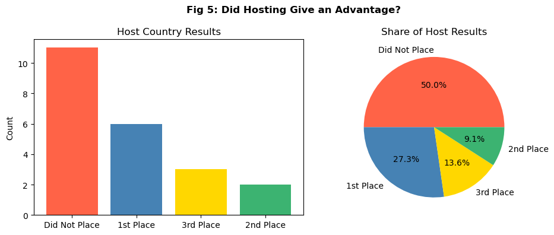

```python
#Figure 5: Correlation Between Teams and Goals

def host_result(row):
    if row['HOST'] == row['CHAMPION']:
        return '1st Place'
    elif row['HOST'] == row['RUNNER UP']:
        return '2nd Place'
    elif row['HOST'] == row['THIRD PLACE']:
        return '3rd Place'
    else:
        return 'Did Not Place'

df['HOST RESULT'] = df.apply(host_result, axis=1)

result_counts = df['HOST RESULT'].value_counts()

colors = ['tomato', 'steelblue', 'gold', 'mediumseagreen']

fig, (ax1, ax2) = plt.subplots(1, 2, figsize=(10, 4))

ax1.bar(result_counts.index, result_counts.values, color=colors)
ax1.set_title('Host Country Results')
ax1.set_ylabel('Count')

ax2.pie(result_counts.values, labels=result_counts.index, colors=colors, autopct='%1.1f%%')
ax2.set_title('Share of Host Results')

plt.suptitle('Fig 5: Did Hosting Give an Advantage?', fontweight='bold')
plt.tight_layout()
plt.show()
```

**Actionable Advice:**

With the 2026 World Cup coming to North America, hosted across the United States, Canada, and Mexico, this will be the largest World Cup in history, featuring 48 teams for the first time. This is a massive opportunity for FIFA, and the trends in our data back it up. Expanding to 48 teams means more matches, more goals, and a bigger global audience than ever before. North America is one of the largest sports markets in the world, and bringing the tournament here gives us a chance to grow the sport in a region where soccer is still gaining popularity.